# Differential detection: simulation strategies

Jeroen Gilis

19/04/2023

# 1 Load libraries

```r
library(scuttle)
library(edgeR)
library(pbapply)
library(harmonicmeanp)
library(stageR)
library(iCOBRA)
library(patchwork)
library(ggplot2)
```

# 2 Helper functions

```r
DD_pb_glm <- function(object){

        # binarize the counts
        object_bin <- object
        assay(object_bin)[assay(object_bin)>=1] <- 1

        # aggregate
        pb_bin <- aggregateAcrossCells(object_bin, ids = object_bin$ind_cov)

        # wrangle
        bin_counts <- as.matrix(assay(pb_bin))
        cd <- colData(pb_bin)

        # compute offset
        offset <- colMeans(sweep(bin_counts, 2, cd$ncells, "/"))
        cd$logitOffset <- log(offset/(1-offset))

        # create formula
        formula <- ~ batch_cov + group_id
        full_formula <- as.formula(paste("cbind(succes,failure)",
                                         paste(formula, collapse = " "),
                                         "+ offset(logitOffset)"))

        # Fit QB-GLM with offset
        mod <- pbapply::pblapply(seq_len(nrow(bin_counts)), function(i){
            cd$succes <- bin_counts[i,]
            cd$failure <- cd$ncells - cd$succes
            mod <- glm(formula = full_formula,
                       family = "quasibinomial",
                       data = cd)
            return(mod)
        })

        # test coefficient of interest
        dfresid_mod <- sapply(mod, function(mod){mod$df.residual})
        sum_mod <- lapply(mod, summary)
        disp <- sapply(sum_mod, function(summod){summod$dispersion})
        beta <- sapply(sum_mod, function(summod){coef(summod)["group_idB",1]})
        var_unscaled <- sapply(sum_mod, function(summod){summod$cov.unscaled["group_idB","group_idB"]})

        # squeeze variance
        hlp <- limma::squeezeVar(var = disp,
                          df = dfresid_mod,
                          robust = FALSE)

        # Compute relevant statistics using squeezed variances
        df_post <- hlp$df.prior + dfresid_mod # posterior DF
        SE <- sqrt(var_unscaled * hlp$var.post) # SE based on squeezed dispersion
        t <- beta / SE # new t-stat
        pval <- pt(-abs(t), df_post) * 2 # new pval

        res <- data.frame(gene = rownames(bin_counts),
                          cluster_id = as.factor("ncM"),
                          logOdds = beta,
                          var_unscaled = var_unscaled,
                          dispersion = disp,
                          dispersion_sq = hlp$var.post,
                          df_prior = hlp$df.prior,
                          df_resid = dfresid_mod,
                          SE = SE,
                          t = t,
                          Wald = (beta^2)/SE,
                          PValue = pval,
                          FDR = p.adjust(pval, method = "BH"),
                          comparsion = "group_idB")
        rownames(res) <- rownames(object)

        return(res)
}
```

```r
DE_pb_edgeR <- function(object){
    pb <- aggregateAcrossCells(object, ids = object$ind_cov)

    y <- DGEList(counts=assay(pb), samples=colData(pb))
    y <- calcNormFactors(y)
    design <- model.matrix(~ factor(batch_cov) + factor(mock_group), y$samples)
    y<-estimateDisp(y,design)
    fit <- glmQLFit(y,design,robust=T)

    res_DGE <- glmQLFTest(fit,coef = ncol(design))
    res_DGE$table$FDR <- p.adjust(res_DGE$table$PValue, method = "BH")

    return(res_DGE)
}
```

```r
visualize_fdrtpr <- function(DD_res, DE_res, truth){
    pvalues <- data.frame(QB_off_squeeze = DD_res$PValue,
                          edgeR_NB = DE_res$PValue)
    #screening stage
    pvalues$pScreen <- apply(X = pvalues,
                             MARGIN = 1,
                             FUN = hmp.stat)
    rownames(pvalues) <- rownames(object)
    cobra <- COBRAData(pval = pvalues, truth = truth)
    cobra <- calculate_adjp(cobra)
    cobraperf <- calculate_performance(cobra,
                                       binary_truth = "is_DE",
                                       splv = "none")
    cobraplot <- prepare_data_for_plot(cobraperf,
                                       colorscheme = "Dark2",
                                       facetted = TRUE)
    gg <- plot_fdrtprcurve(cobraplot) +
        theme(strip.background = element_blank(),
        strip.text.x = element_blank(),
        plot.title = element_text(size=10),
        axis.text.x = element_text(size = 10),
        axis.text.y = element_text(size = 10),
        axis.title.x = element_text(size = 10),
        axis.title.y = element_text(size = 10))
    return(gg)
}
```

# 3 Load and inspect data

```
set.seed(654146546)
object_orig <- simulate_DE(x = sce_list[[1]],
                      groups = sce_list[[1]]$mock_group,
                      prop_DE = 0.05)
saveRDS(object_orig, "/Users/jg/Desktop/PhD/DD_project/object_orig.rds")
```

```r
object_orig <- readRDS("/Users/jg/Desktop/PhD/DD_project/object_orig.rds")
object <- object_orig
object$group_id <- object$mock_group
table(rowData(object)$is_DE)
```

```
##
## FALSE  TRUE
##  5777   304
```

```r
object <- object[!rowData(object)$is_DE,]
ngenes <- 300 # slightly more than 5%

set.seed(65454)
genes_to_change <- sample(rownames(object), ngenes)
```

```r
hlp <- assay(object)[genes_to_change,object$mock_group=="B"]
ncol(hlp)
```

```
## [1] 2902
```

```r
range(rowSums(hlp > 0))
```

```
## [1]  117 2886
```

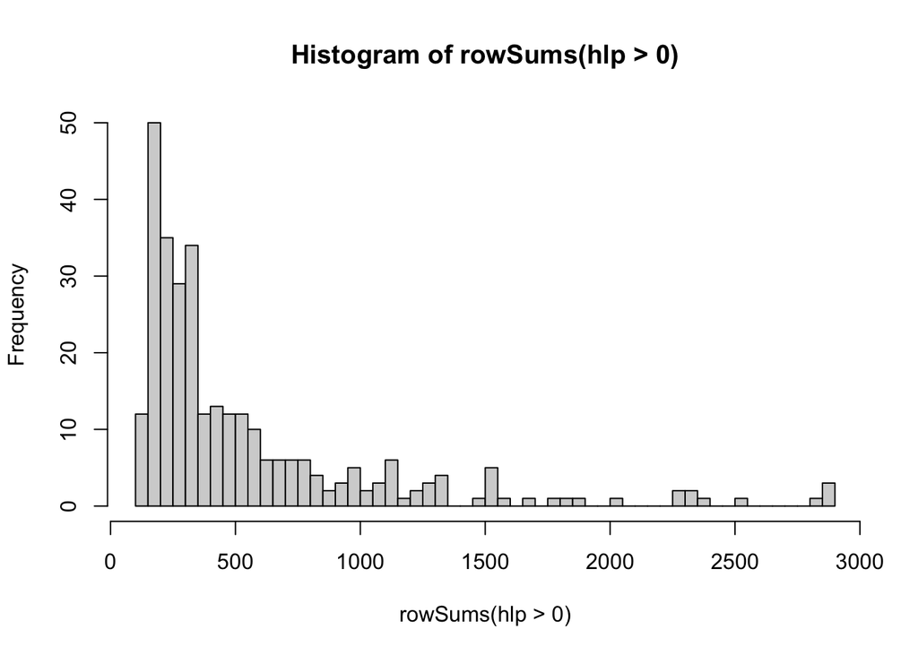

```r
hist(rowSums(hlp > 0), breaks=40)
```

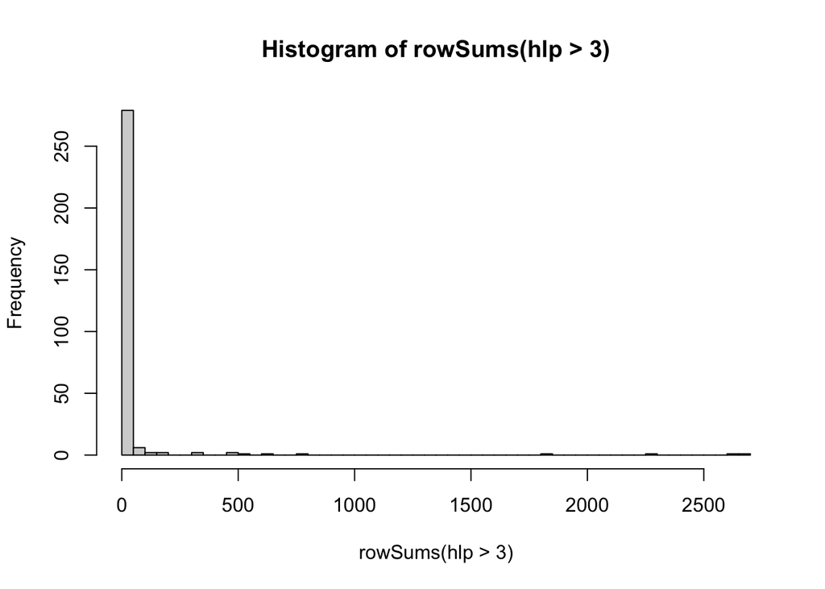

```r
hist(rowSums(hlp > 3), breaks=40)
```

```r
sum(hlp == 0)/(ncol(hlp)*nrow(hlp))
```

```
## [1] 0.8106984
```

```r
sum(hlp == 1)/(ncol(hlp)*nrow(hlp))
```

```
## [1] 0.1303641
```

```r
sum(hlp == 2)/(ncol(hlp)*nrow(hlp))
```

```
## [1] 0.03116012
```

```r
sum(hlp == 3)/(ncol(hlp)*nrow(hlp))
```

```
## [1] 0.01068114
```

```r
sum(hlp > 3)/(ncol(hlp)*nrow(hlp))
```

```
## [1] 0.01709626
```

# 4 Introduce DD

Now introduce DD in three other ways:

1. Randomly replace some of the counts with zeroes in 1 mock group. This will introduce DD, but also shift the mean and introduce DE

Note, we may alternate between mock groups where we make the change. I.e., for 50% of the genes fill in zeroes in mock A, for the other half in mock B. That way, we wont generate imbalances in sequencing depth between the mock groups.

2. Replace some of the counts with zeroes, but only do this for the lowest counts. This will introduce both DD and DE, but the mean will be shifted less. It could also correspond more closely to what happens in real life.
3. Again add zeroes in 1 mock group, but add the values that went to zero to other cells in that group. Thus the mean will not be shifted (no DE), but the variance will be shifted

## 4.1 DD option 1

```r
DD_option1 <- function(object, genes_to_change, frac_cells){

    hlp_a <- assay(object)[genes_to_change[1:(length(genes_to_change)/2)],object$mock_group=="A"]
    hlp_b <- assay(object)[genes_to_change[(length(genes_to_change)/2+1):length(genes_to_change)],object$mock_group=="B"]

    vec_zero <- c(round(rowSums(hlp_a > 0) * frac_cells) ,
                  round(rowSums(hlp_b > 0) * frac_cells))

    for (i in 1:nrow(hlp_a)) {
        nonzero <- which(hlp_a[i,] > 0)
        n_zero <- round(length(nonzero)*frac_cells)
        hlp_a[i,sample(nonzero, n_zero)] <- 0
    }

    for (i in 1:nrow(hlp_b)) {
        nonzero <- which(hlp_b[i,] > 0)
        n_zero <- round(length(nonzero)*frac_cells)
        hlp_b[i,sample(nonzero, n_zero)] <- 0
    }

    assay(object)[rownames(hlp_a),object$mock_group=="A"] <- hlp_a
    assay(object)[rownames(hlp_b),object$mock_group=="B"] <- hlp_b

    rowData(object)$DD_1 <- NA
    rowData(object[names(vec_zero),])$DD_1 <- vec_zero
    rowData(object[names(vec_zero),])$is_DE <- TRUE
    return(object)
}
```

```r
set.seed(64564)
objectList_1 <- vector(mode = "list", length = 10)
fracs <- seq(0.05, 0.5, 0.05)
for (i in 1:10) {
    print(i)
    objectList_1[[i]] <- DD_option1(object = object,
                                    genes_to_change = genes_to_change,
                                    frac_cells = fracs[i])
}
```

```r
# DD analysis on each dataset
resList_DD_1 <- lapply(objectList_1, DD_pb_glm)

# DE analysis on each dataset
resList_DE_1 <- pblapply(objectList_1, DE_pb_edgeR)

resList_1 <- list(DD = resList_DD_1,
                  DE = resList_DE_1)
saveRDS(resList_1, "resList_1.Rds")
```

## 4.2 DD option 2

In stead of randomly setting the expression of cells with counts to zero, we do this for the first n cells, after sorting on expression levels. Hence, small expression values are set to zero first. In practice, this will result in only 1’s being set to zero.

```r
DD_option2 <- function(object, genes_to_change, frac_cells){

    hlp_a <- assay(object)[genes_to_change[1:(length(genes_to_change)/2)],object$mock_group=="A"]
    hlp_b <- assay(object)[genes_to_change[(length(genes_to_change)/2+1):length(genes_to_change)],object$mock_group=="B"]

    vec_zero <- c(round(rowSums(hlp_a > 0) * frac_cells) ,
                  round(rowSums(hlp_b > 0) * frac_cells))

    for (i in 1:nrow(hlp_a)) {
        nonzero <- which(hlp_a[i,] > 0)
        n_zero <- round(length(nonzero)*frac_cells)
        count_vec <- sort(hlp_a[i,names(nonzero)])
        hlp_a[i,names(count_vec)[1:n_zero]] <- 0
    }

    for (i in 1:nrow(hlp_b)) {
        nonzero <- which(hlp_b[i,] > 0)
        n_zero <- round(length(nonzero)*frac_cells)
        count_vec <- sort(hlp_b[i,names(nonzero)])
        hlp_b[i,names(count_vec)[1:n_zero]] <- 0
    }

    assay(object)[rownames(hlp_a),object$mock_group=="A"] <- hlp_a
    assay(object)[rownames(hlp_b),object$mock_group=="B"] <- hlp_b

    rowData(object)$DD_1 <- NA
    rowData(object[names(vec_zero),])$DD_1 <- vec_zero
    rowData(object[names(vec_zero),])$is_DE <- TRUE
    return(object)
}
```

```r
#set.seed(64564)
objectList_2 <- vector(mode = "list", length = 10)
fracs <- seq(0.05, 0.5, 0.05)
for (i in 1:10) {
    print(i)
    objectList_2[[i]] <- DD_option2(object = object,
                                    genes_to_change = genes_to_change,
                                    frac_cells = fracs[i])
}
```

```r
# DD analysis on each dataset
resList_DD_2 <- lapply(objectList_2, DD_pb_glm)

# DE analysis on each dataset
resList_DE_2 <- pblapply(objectList_2, DE_pb_edgeR)

resList_2 <- list(DD = resList_DD_2,
                  DE = resList_DE_2)
saveRDS(resList_2, "resList_2.Rds")
```

## 4.3 DD option 3

We again add zeroes in 1 mock group, but add the values that went to zero to other cells in that group. Thus, the mean will not be shifted (no DE). However, the variance will shift, and we may end up generating bimodal distributions.

```r
DD_option3 <- function(object, genes_to_change, frac_cells){

    hlp_a <- assay(object)[genes_to_change[1:(length(genes_to_change)/2)],object$mock_group=="A"]
    hlp_b <- assay(object)[genes_to_change[(length(genes_to_change)/2+1):length(genes_to_change)],object$mock_group=="B"]

    vec_zero <- c(round(rowSums(hlp_a > 0) * frac_cells) ,
                  round(rowSums(hlp_b > 0) * frac_cells))

    for (i in 1:nrow(hlp_a)) {
        nonzero <- names(which(hlp_a[i,] > 0))
        n_zero <- round(length(nonzero)*frac_cells)

        # change some to zero
        change_to_zero <- sample(nonzero, n_zero)
        former_counts <- sum(unname(hlp_a[i,change_to_zero])) # store sum of counts set to zero
        hlp_a[i,change_to_zero] <- 0

        # add back the removed counts to the other cells
        not_change_to_zero <- nonzero[!nonzero %in% change_to_zero]
        hlp_add <- table(sample(not_change_to_zero,
                                former_counts,
                                replace = TRUE)) # redistribute the formerly removed counts
        hlp_a[i,names(hlp_add)] <- as.matrix(hlp_a[i,names(hlp_add)] + hlp_add)
    }

    for (i in 1:nrow(hlp_b)) {
        nonzero <- names(which(hlp_b[i,] > 0))
        n_zero <- round(length(nonzero)*frac_cells)

        # change some to zero
        change_to_zero <- sample(nonzero, n_zero)
        former_counts <- sum(unname(hlp_b[i,change_to_zero])) # store sum of counts set to zero
        hlp_b[i,change_to_zero] <- 0

        # add back the removed counts to the other cells
        not_change_to_zero <- nonzero[!nonzero %in% change_to_zero]
        hlp_add <- table(sample(not_change_to_zero,
                                former_counts,
                                replace = TRUE)) # redistribute the formerly removed counts
        hlp_b[i,names(hlp_add)] <- as.matrix(hlp_b[i,names(hlp_add)] + hlp_add)
    }

    assay(object)[rownames(hlp_a),object$mock_group=="A"] <- hlp_a
    assay(object)[rownames(hlp_b),object$mock_group=="B"] <- hlp_b

    rowData(object)$DD_1 <- NA
    rowData(object[names(vec_zero),])$DD_1 <- vec_zero
    rowData(object[names(vec_zero),])$is_DE <- TRUE
    return(object)
}
```

```r
set.seed(18967)
objectList_3 <- vector(mode = "list", length = 10)
fracs <- seq(0.05, 0.5, 0.05)
for (i in 1:10) {
    print(i)
    objectList_3[[i]] <- DD_option3(object = object,
                                    genes_to_change = genes_to_change,
                                    frac_cells = fracs[i])
}
```

```r
# DD analysis on each dataset
resList_DD_3 <- lapply(objectList_3, DD_pb_glm)

# DE analysis on each dataset
resList_DE_3 <- pblapply(objectList_3, DE_pb_edgeR)

resList_3 <- list(DD = resList_DD_3,
                  DE = resList_DE_3)
saveRDS(resList_3, "resList_3.Rds")
```

# 5 Visualize results

```r
resList_1 <- readRDS("resList_1.Rds")
resList_2 <- readRDS("resList_2.Rds")
resList_3 <- readRDS("resList_3.Rds")
```

## 5.1 Quick check

Quickly compare results by looking at the #TP

```r
for(i in seq_along(resList_1$DD)){
    print(c(sum(resList_1$DD[[i]][genes_to_change, "FDR"] < 0.05),
            sum(resList_1$DE[[i]]$table[genes_to_change, "FDR"] < 0.05)))
}
```

```
## [1] 6 0
## [1] 18  6
## [1] 54 27
## [1] 104  74
## [1] 178 145
## [1] 230 205
## [1] 264 252
## [1] 283 275
## [1] 295 293
## [1] 298 298
```

```r
for(i in seq_along(resList_2$DD)){
    print(c(sum(resList_2$DD[[i]][genes_to_change, "FDR"] < 0.05),
            sum(resList_2$DE[[i]]$table[genes_to_change, "FDR"] < 0.05)))
}
```

```
## [1] 4 0
## [1] 17  0
## [1] 54  2
## [1] 108  13
## [1] 182  71
## [1] 225 160
## [1] 262 217
## [1] 282 250
## [1] 294 269
## [1] 299 287
```

```r
for(i in seq_along(resList_3$DD)){
    print(c(sum(resList_3$DD[[i]][genes_to_change, "FDR"] < 0.05),
            sum(resList_3$DE[[i]]$table[genes_to_change, "FDR"] < 0.05)))
}
```

```
## [1] 4 0
## [1] 18  0
## [1] 54  0
## [1] 112   0
## [1] 172   0
## [1] 229   0
## [1] 268   0
## [1] 286   0
## [1] 294   0
## [1] 299   0
```

## 5.2 FDR-TPR

```r
# truth is the same for all datasets
truth <- data.frame(gene = rownames(object),
                    is_DE = FALSE)
truth$is_DE[truth$gene %in% genes_to_change] <- TRUE
rownames(truth) <- truth$gene
```

### 5.2.1 dataset 1

```r
gg_list_1 <- lapply(1:10, function(i){
    DD_res <- resList_1$DD[[i]]
    DE_res <- resList_1$DE[[i]]$table
    gg <- visualize_fdrtpr(DD_res = DD_res,
                           DE_res = DE_res,
                           truth = truth)
})
```

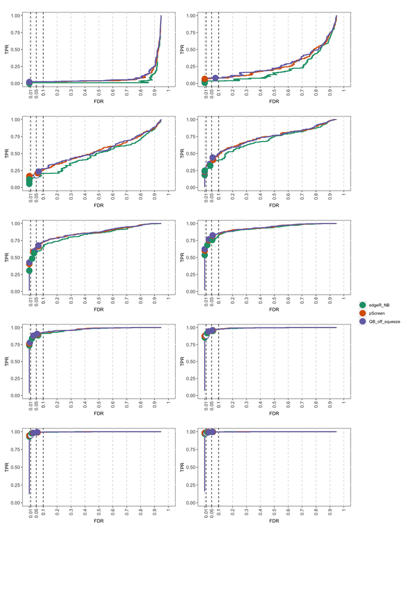

```r
(gg_list_1[[1]] + gg_list_1[[2]] + gg_list_1[[3]] + gg_list_1[[4]])/
    (gg_list_1[[5]] + gg_list_1[[6]] + gg_list_1[[7]] + gg_list_1[[8]])/
    (gg_list_1[[9]] + gg_list_1[[10]] + plot_spacer() + plot_spacer()) + plot_layout(guides = "collect")
```

### 5.2.2 dataset 2

```r
gg_list_2 <- lapply(1:10, function(i){
    DD_res <- resList_2$DD[[i]]
    DE_res <- resList_2$DE[[i]]$table
    gg <- visualize_fdrtpr(DD_res = DD_res,
                           DE_res = DE_res,
                           truth = truth)
})
```

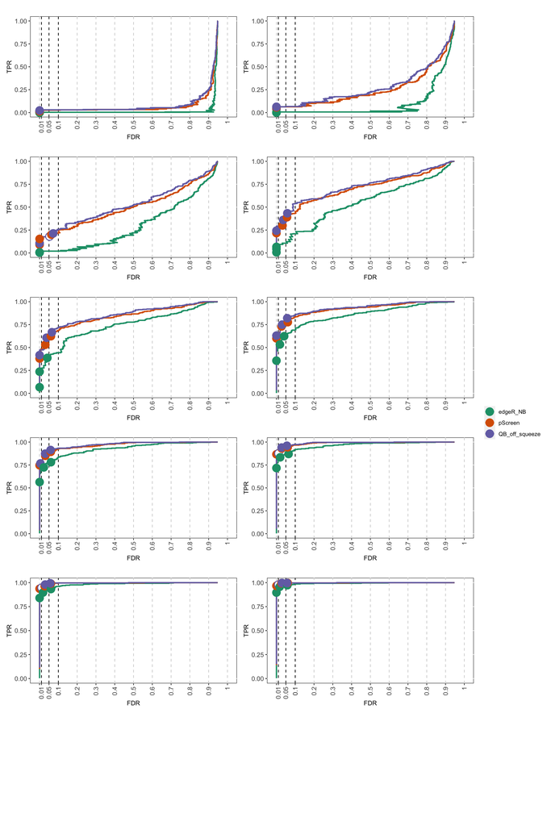

```r
(gg_list_2[[1]] + gg_list_2[[2]] + gg_list_2[[3]] + gg_list_2[[4]])/
    (gg_list_2[[5]] + gg_list_2[[6]] + gg_list_2[[7]] + gg_list_2[[8]])/
    (gg_list_2[[9]] + gg_list_2[[10]] + plot_spacer() + plot_spacer()) + plot_layout(guides = "collect")
```

### 5.2.3 dataset 3

```r
gg_list_3 <- lapply(1:10, function(i){
    DD_res <- resList_3$DD[[i]]
    DE_res <- resList_3$DE[[i]]$table
    gg <- visualize_fdrtpr(DD_res = DD_res,
                           DE_res = DE_res,
                           truth = truth)
})
```

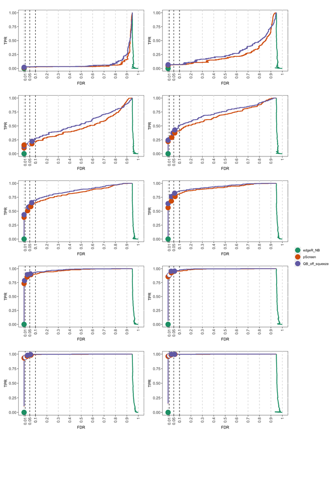

```r
(gg_list_3[[1]] + gg_list_3[[2]] + gg_list_3[[3]] + gg_list_3[[4]])/
    (gg_list_3[[5]] + gg_list_3[[6]] + gg_list_3[[7]] + gg_list_3[[8]])/
    (gg_list_3[[9]] + gg_list_3[[10]] + plot_spacer() + plot_spacer()) + plot_layout(guides = "collect")
```